# Predictive maintenance

Course final project

TIME SERIES ANALYSIS

10/02/2022

[figure not shown]

Predictive maintenance analysis are designed to help determine the condition of in-service equipment in order to estimate when maintenance should be performed. This approach promises cost savings over routine or time-based preventive maintenance, because tasks are performed only when warranted.

# Dataset

Data files provided are the following:

| File Name | Description |
| --- | --- |
| allarmi_30147127.csv | Alarms releted to pressure |
| p_30147127.csv | Pressure values |

## Alarms data

```r
alarms<- read.csv('allarmi_30147127.csv')
str(alarms)
```

```
## 'data.frame':    171 obs. of  2 variables:
##  $ date_time: chr  "2018-04-10 07:40:42" "2018-04-10 07:42:23" "2018-11-13 09:22:19" "2018-11-14 10:03:21" ...
##  $ priorita : chr  "alta" "bassa" "bassa" "bassa" ...
```

### Variables/features

- *date_time*: Time stamp
- *priorità*: Alarms related to pressure transmitter’s status (alto-basso-medio –> refers to transmitter’s values class range )

```
## 1 seconds periodicity from 2018-04-10 07:40:42 to 2019-01-08 10:41:04
```

Alarms status

| date_time | priorita |
| --- | --- |
| 2018-04-10 07:40:42 | alta |
| 2018-04-10 07:42:23 | bassa |
| 2018-11-13 09:22:19 | bassa |
| 2018-11-14 10:03:21 | bassa |
| 2018-11-27 09:15:33 | alta |
| 2018-12-04 08:55:03 | media |

## Pressure values data

```r
pressures<- read.csv("p_30147127.csv")
str(pressures)
```

```
## 'data.frame':    20625 obs. of  2 variables:
##  $ ts   : chr  "2018-03-18 00:00:00" "2018-03-18 00:15:00" "2018-03-18 00:30:00" "2018-03-18 00:45:00" ...
##  $ value: num  23.7 23.7 23.7 23.7 23.7 ...
```

### Variables/features

- *ts*: Time stamp
- *value*: Data values of an specific pressure transmitter

```
## 15 minute periodicity from 2018-03-18 to 2019-04-17 23:00:00
```

Pressure values

| ts | value |
| --- | --- |
| 2018-03-18 00:00:00 | 23.69 |
| 2018-03-18 00:15:00 | 23.70 |
| 2018-03-18 00:30:00 | 23.70 |
| 2018-03-18 00:45:00 | 23.71 |
| 2018-03-18 01:00:00 | 23.71 |
| 2018-03-18 01:15:00 | 23.71 |

# Training and validadions

The subsetting data for train and validationd must take into account the follow partition:

- training data: [<= “2019-04-14”]
- validations data: [> “2019-04-14”]

# Evaluations

The goal is to build a forecasting models, using ARIMA and VAR/VECM models, that will provide the following information:

- forecasting pressure transmitter’s values

# Submission file

- The submission file must be uploaded in moodle. Deadline [`10/02/21 h 13:30`]
- For submission file use Markdown format (by Python or R) and must include:
  - `.Rmd or.ipynb;`
  - `.html`
- The submitted file should be formatted as:
  - `author and file names`: (student’s name and surname)
  - `chunk options`: show code and output; no warnings and no messages
- formatted as follows `sections` and `subsection`:
  - `Data explorations`: (section)
  - `Data Preprocessing`: (section)
  - `Data model`[ARIMA] (section)
    - training: (subsection)
    - validations: (subsection)
    - forecasting: (subsection)
  - `Data model`[VAR/VECM] (section)
    - training: (subsection)
    - validations: (subsection)
    - forecasting: (subsection)

# Guidelines

> recode alarms: from character to numeric

> manage periodicity and frequency

> regularize timestamp

> exemple of final forecasting’ output should be include forecasting preussure values and evidence of alarms status:

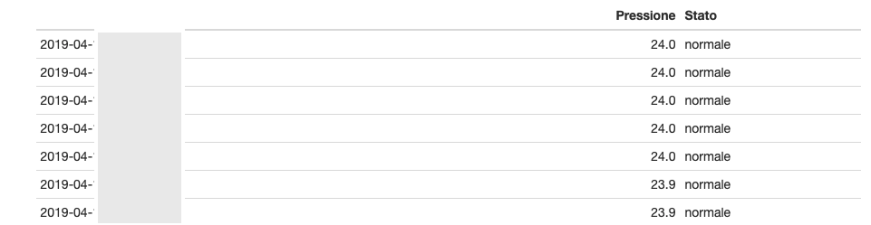